# Accessibility Links

# Search Results

### How to Cope With Anxiety

Verywell Health

https://www.verywellhealth.com › ... › Anxiety Disorders

To cope with immediate anxiety, *try interrupting negative thought patterns with positive ones*, deep breathing exercises, grounding techniques, getting exercise ...

### 10 Ways to Effectively Cope With Anxiety

Davis Behavioral Health

https://www.dbhutah.org › effectively-coping-with-anxi...

Apr 23, 2020 — Effectively Coping With Anxiety · *Put Away the Phone* · Rely on Trusted Sources for Information · Sleep · Limit Caffeine · Practice Mindfulness.

### Coping with anxiety

Childline

https://www.childline.org.uk › anxiety-stress-panic › anx...

Ways to cope with anxiety · *Focus on your breathing and your body* · Try to recognise negative thoughts · Give yourself time to worry · Talk about things · Keep ...

### How do you overcome anxiety in the moment? : r/Mindfulness

Reddit · r/Mindfulness

80+ comments · 2 years ago

*Deep breathing techniques, visualization, talking to someone*, doing some physical exercise to get the anxious energy out, meditate, try to ...

### Generalised anxiety disorder (GAD)

nhs.uk

https://www.nhs.uk › ... › Mental health conditions

Treatment for generalised anxiety disorder (GAD) · *talking therapies – usually cognitive behavioural therapy (CBT*) with the support of a therapist, either by ...

### Coping with Anxiety: Strategies to Regain Control

University of Utah Health

https://healthcare.utah.edu › healthfeed › 2025/02 › copi...

Feb 7, 2025 — *Go on a walk or move your body in some way*; Talk to someone you trust about how you're feeling; Accept your feelings, as pushing them away ...

### What You Can Do to Cope With Anxiety

Verywell Mind

https://www.verywellmind.com › ... › Coping

Aug 1, 2024 — This article discusses some of the strategies that may help you cope with anxiety, including *breathing exercises, distraction, and self-care*.

American Psychological Association (APA)

https://www.apa.org › monitor › 2025/06 › anticipatory...

### People with anxiety; what are your coping methods?

Reddit · r/AskReddit

1.8K+ comments · 6 years ago

*Mindfulness meditation*. Sit straight up, put my headphones on, listen to ten minutes of relaxing music, try not to think about anything but my ...

Images

[figure not shown]

How to Cope With Anxiety

Verywell Health

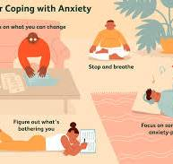

Coping With Anxiety: 5 Ways to Deal With Anxiety

Verywell Mind

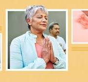

How to Cope With Anxiety and Depression

Everyday Health

Show more images

People also search for

How to **deal** with anxiety **when alone**

How to **reduce** anxiety **immediately**

How to cope with anxiety **and overthinking**

How to **deal** with anxiety **and depression**

How to **stop** anxiety **thoughts**

**Ways** to **calm** anxiety **attack**

**5 ways** to **deal** with anxiety

How to **deal** with anxiety **without medication**

# Footer Links

- From your IP address

[interactive chart not shown]